# Lab Exercise 1: Introduction to estimating diversification rates

### 1. Lineage through time plots

To get started, let’s load phytools & dependencies and set the working directory (remember, you need to point to the appropriate directory on your computer).

```r
library(phytools)
setwd("/Users/michael_alfaro/Dropbox/teaching/200a2016/lab-1-tree-sims/")
```

Next, let’s load a tree from file: [etheostoma_percina_chrono.tre](https://www.dropbox.com/s/aaggo5iki18apt4/etheostoma_percina_chrono.tre?dl=0).

```r
setwd("/Users/michael_alfaro/Dropbox/teaching/200a2016/lab-1-tree-sims/")
darter.tree<-read.tree("etheostoma_percina_chrono.tre")
```

Our tree is from [Near et al. (2011)](https://paperpile.com/shared/BAQU0J). In it, they sampled 201 of 216 species from the group (93%) - but for the purposes of this exercise (and the next), we will assume 100% sampling.

Let’s first plot the tree:

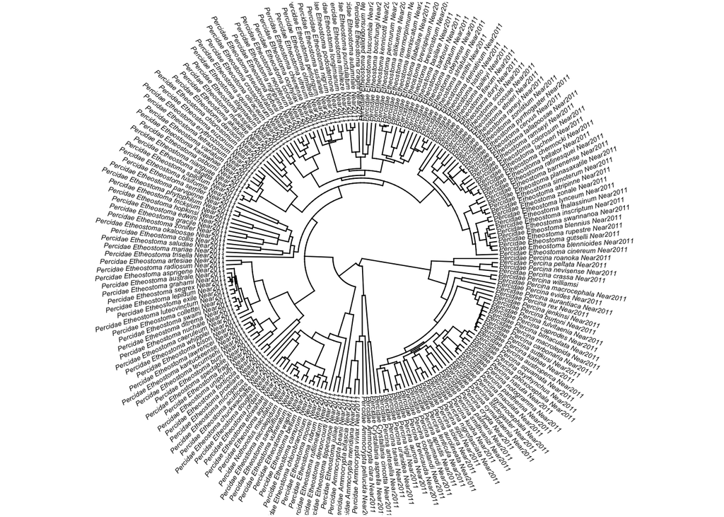

```r
plotTree(darter.tree,ftype="i",fsize=0.4,type="fan",lwd=1)
```

Now let’s use the function ltt in the phytools package to generate a LTT plot:

```r
obj<-ltt(darter.tree,log.lineages=FALSE)
```

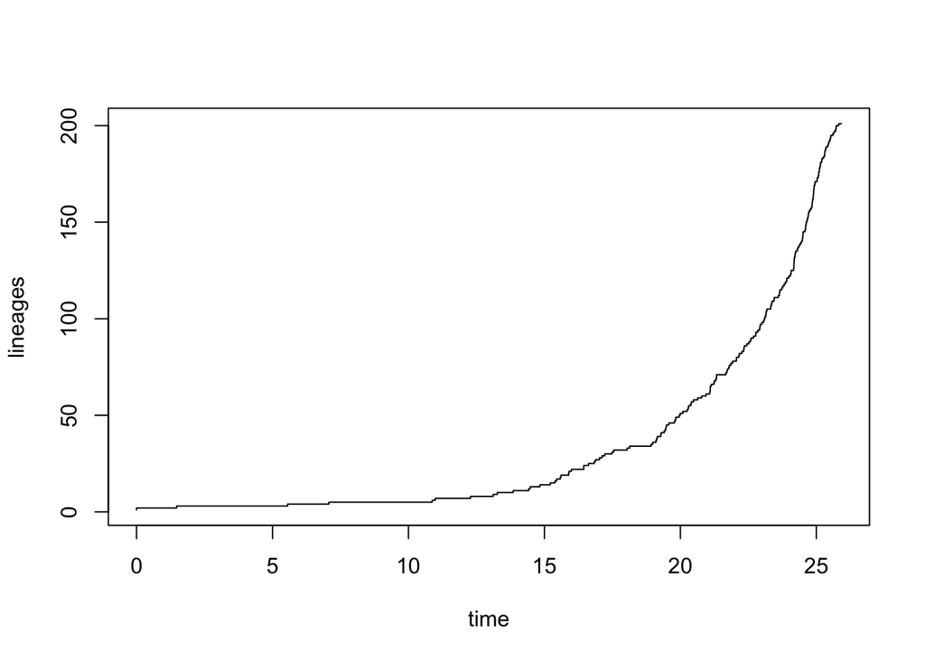

obj

```r
darter.tree
```

```
##
## Phylogenetic tree with 201 tips and 198 internal nodes.
##
## Tip labels:
##  Percidae_Etheostoma_cinereum_Near2011, Percidae_Etheostoma_blennioides_Near2011, Percidae_Etheostoma_gutselli_Near2011, Percidae_Etheostoma_rupestre_Near2011, Percidae_Etheostoma_blennius_Near2011, Percidae_Etheostoma_swannanoa_Near2011, ...
##
## Rooted; includes branch lengths.
```

A fully birfucating tree with N tips will have N-1 internal nodes.

```r
is.binary(darter.tree)
```

```
## [1] FALSE
```

```r
darter.tree<-multi2di(darter.tree)
darter.tree
```

```
##
## Phylogenetic tree with 201 tips and 200 internal nodes.
##
## Tip labels:
##  Percidae_Etheostoma_cinereum_Near2011, Percidae_Etheostoma_blennioides_Near2011, Percidae_Etheostoma_gutselli_Near2011, Percidae_Etheostoma_rupestre_Near2011, Percidae_Etheostoma_blennius_Near2011, Percidae_Etheostoma_swannanoa_Near2011, ...
##
## Rooted; includes branch lengths.
```

```r
is.binary(darter.tree)
```

```
## [1] TRUE
```

We have randomly resolved the internal nodes that were multifurcating….

```r
obj<-ltt(darter.tree,plot=FALSE)
obj
```

```
## Object of class "ltt" containing:
##
## (1) A phylogenetic tree with 201 tips and 200 internal nodes.
##
## (2) Vectors containing the number of lineages (ltt) and branching times (times) on the tree.
##
## (3) A value for Pybus & Harvey's "gamma" statistic of 0.2007, p-value = 0.841.
```

Let’s have a look at the new LTT plot

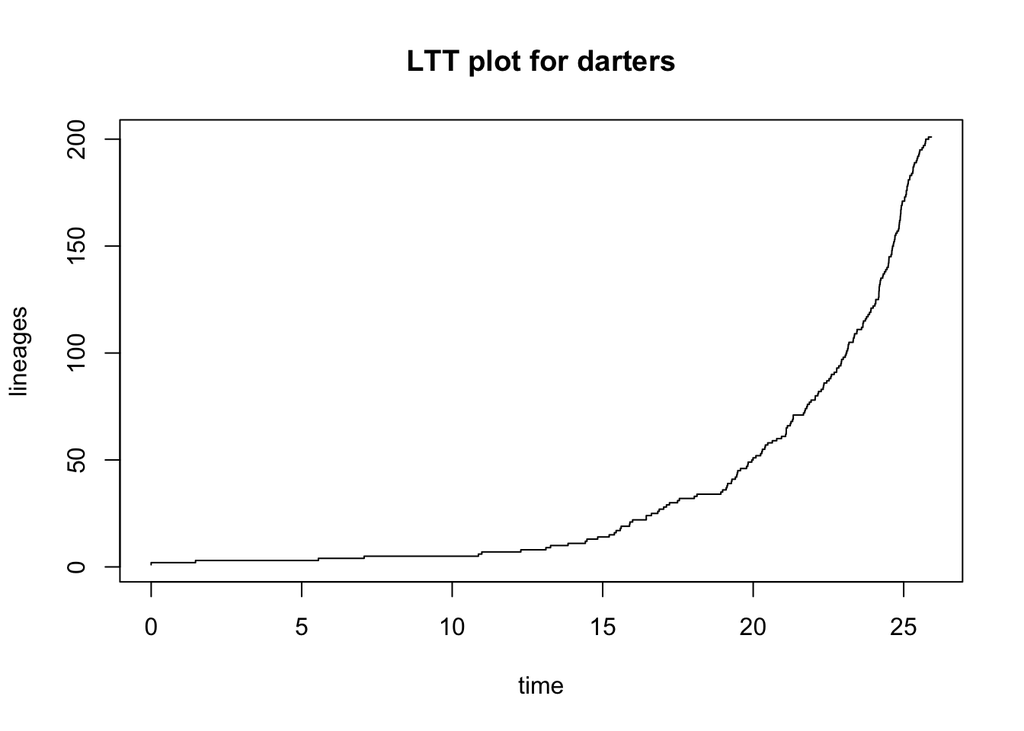

```r
plot(obj,log.lineages=FALSE,main="LTT plot for darters")
```

Here we plot the tree and the LTT plot together….

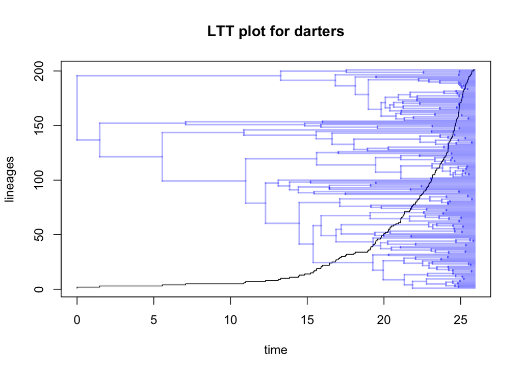

```r
plot(obj,show.tree=TRUE,log.lineages=FALSE,main="LTT plot for darters")
```

Note that under pure-birth, the number of lineages should rise exponentially through time. By convention, and because it linearizes the expectation under pure-birth, we normally would plot our pure-birth trees on a semi-log scale, meaning that the vertical axis is on a log-scale while our horizontal axis is on a linear scale.

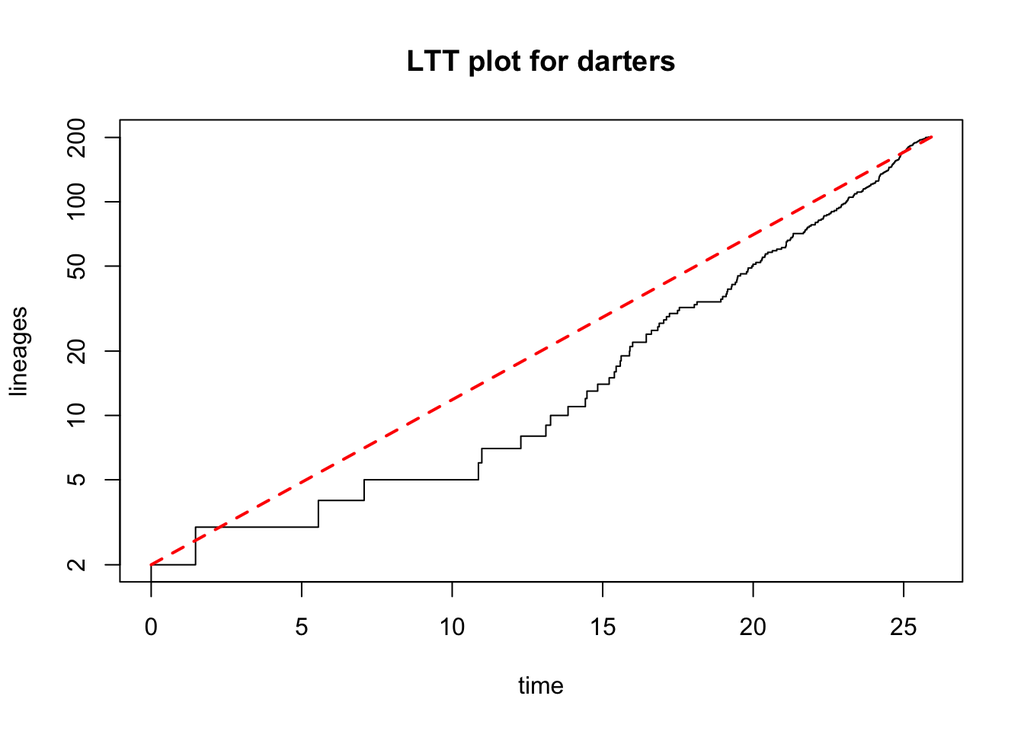

```r
plot(obj,log.lineages=FALSE,log="y",main="LTT plot for darters",
    ylim=c(2,Ntip(darter.tree)))
## we can overlay the pure-birth prediction:
h<-max(nodeHeights(darter.tree))
x<-seq(0,h,by=h/100)
b<-(log(Ntip(darter.tree))-log(2))/h
lines(x,2*exp(b*x),col="red",lty="dashed",lwd=2)
```

We might like to compare the observed LTT, to simulated LTTs assuming a pure-birth process of the same duration & resulting in the same total number of species. We can do this using the phytools function pbtree:

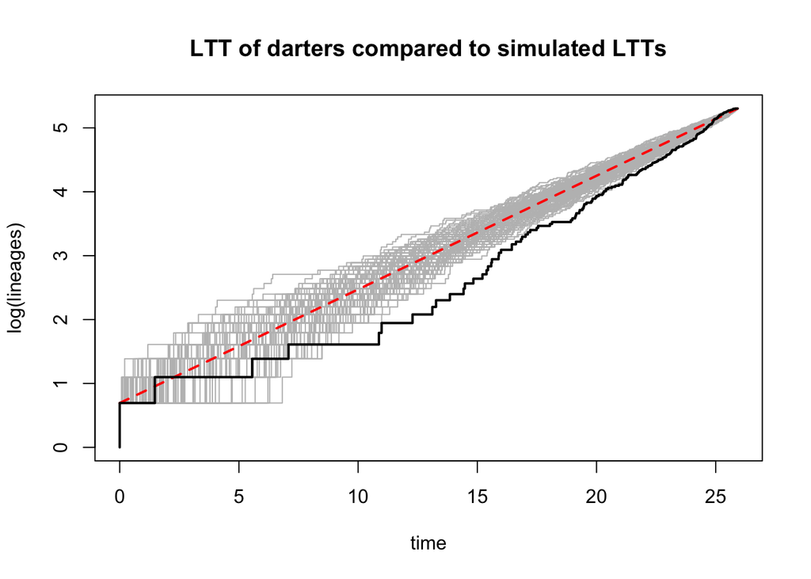

```
## Object of class "ltt" containing:
##
## (1) A phylogenetic tree with 201 tips and 200 internal nodes.
##
## (2) Vectors containing the number of lineages (ltt) and branching times (times) on the tree.
##
## (3) A value for Pybus & Harvey's "gamma" statistic of 0.2007, p-value = 0.841.
```

```r
trees<-pbtree(b=b,n=Ntip(darter.tree),t=h,nsim=100,method="direct",
    quiet=TRUE)
obj<-ltt(trees,plot=FALSE)
plot(obj,col="grey",main="LTT of darters compared to simulated LTTs")
lines(c(0,h),log(c(2,Ntip(darter.tree))),lty="dashed",lwd=2,col="red")
## now let's overlay our original tree
ltt(darter.tree,add=TRUE,lwd=2)
```

Alternatively, the function ltt95 gives a (1-α)% CI for the LTT based on a set of trees. We use it here using a simulated distribution of trees, but this might also be useful if we have, for example, a set of trees from the posterior distribution of a Bayesian analysis:

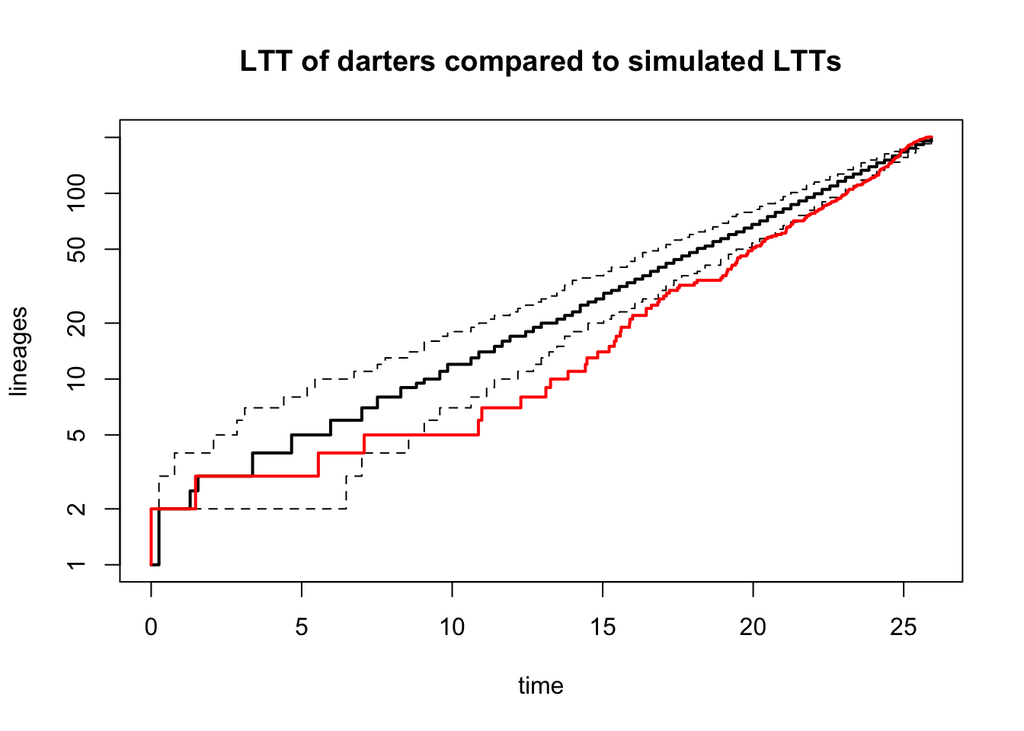

```
## Object of class "ltt" containing:
##
## (1) A phylogenetic tree with 201 tips and 200 internal nodes.
##
## (2) Vectors containing the number of lineages (ltt) and branching times (times) on the tree.
##
## (3) A value for Pybus & Harvey's "gamma" statistic of 0.2007, p-value = 0.841.
```

```r
ltt95(trees,log=TRUE)
title(main="LTT of darters compared to simulated LTTs")
ltt(darter.tree,add=TRUE,log.lineages=FALSE,col="red",lwd=2)
```

### 2. Fitting pure birth and birth-death models to trees.

```r
library(phytools)
fitbd <- birthdeath(darter.tree)
fitbd
```

```
##
## Estimation of Speciation and Extinction Rates
##             with Birth-Death Models
##
##      Phylogenetic tree: darter.tree
##         Number of tips: 201
##               Deviance: -741.7514
##         Log-likelihood: 370.8757
##    Parameter estimates:
##       d / b = 0.06330651   StdErr = 0.1640933
##       b - d = 0.2212409   StdErr = 0.02342254
##    (b: speciation rate, d: extinction rate)
##    Profile likelihood 95% confidence intervals:
##       d / b: [-0.1838519, 0.2583648]
##       b - d: [0.1914747, 0.2539717]
```

**birthdeath()** reports compund parameters, d/b (extinction fraction) and b-d (net diversification). To get the b and d rates separately we will use a phytools function, **bd()**

```r
bd(fitbd)
```

```
##          b          d
## 0.23619344 0.01495258
```

One problem with this function is that the birth and death rates are conditioned on full sampling of the tree. This is not the case for the darter tree but we will not pursue more appropriate rate estimatation here.

### 3. The γ-statistic

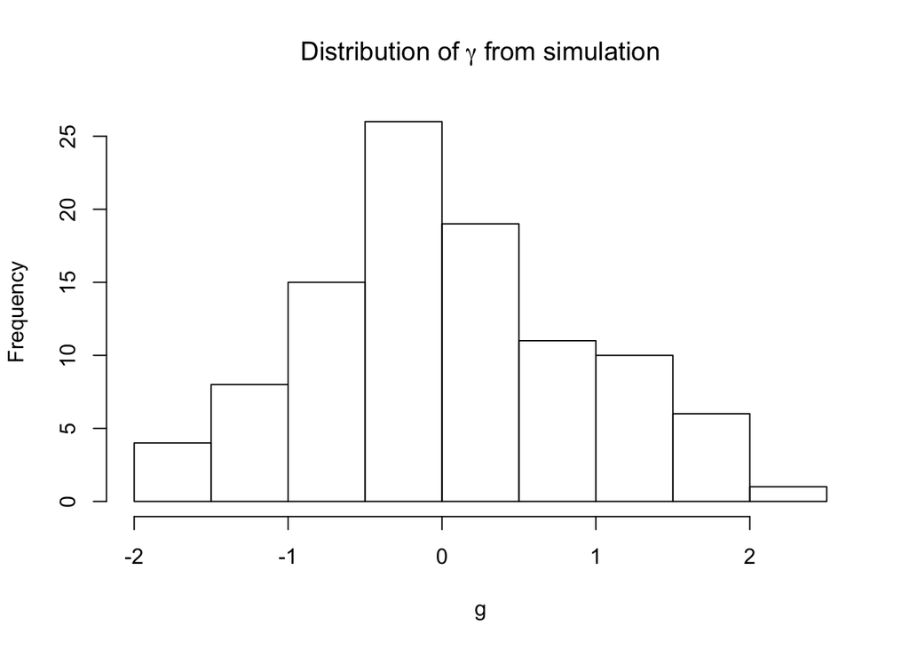

```r
g<-sapply(trees,function(x) ltt(x,plot=FALSE)$gamma)
hist(g,main=expression(paste("Distribution of ",gamma," from simulation")))
```

```r
mean(g)
```

```
## [1] 0.07115087
```

```r
var(g)
```

```
## [1] 0.841266
```

We can test hypotheses about γ. This is done automatically with ltt. For example

```r
obj<-ltt(darter.tree,plot=FALSE)
print(obj)
```

```
## Object of class "ltt" containing:
##
## (1) A phylogenetic tree with 201 tips and 200 internal nodes.
##
## (2) Vectors containing the number of lineages (ltt) and branching times (times) on the tree.
##
## (3) A value for Pybus & Harvey's "gamma" statistic of 0.2007, p-value = 0.841.
```

Note that the p value returned by **ltt()** assumes that the tree is fully sampled. Is this the case for your tree?

Finally, let’s simulate a tree under a different model of lineage accumulation - the coalescent - and see what the result is. Theoretically, this should result in a significantly positive γ.

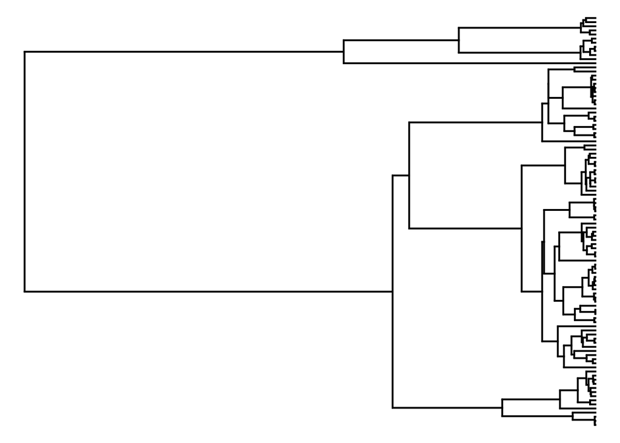

```r
coal.tree<-rcoal(n=100)
plotTree(coal.tree,ftype="off")
```

```r
obj<-ltt(coal.tree,log.lineages=FALSE,log="y")
```

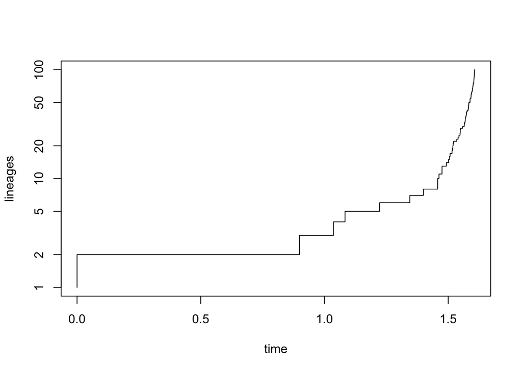

```r
darter.gamma <- obj$gamma # ltt returns a gamma value as one of its elements
```

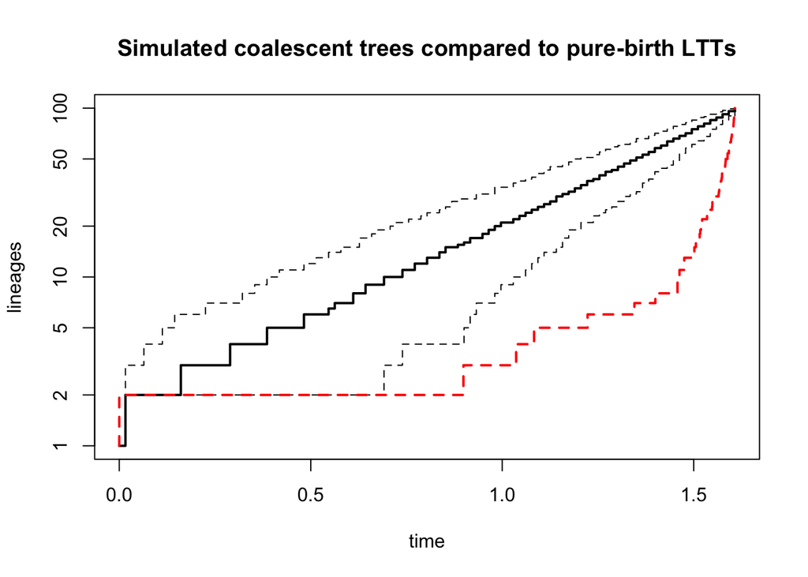

```
## Object of class "ltt" containing:
##
## (1) A phylogenetic tree with 100 tips and 99 internal nodes.
##
## (2) Vectors containing the number of lineages (ltt) and branching times (times) on the tree.
##
## (3) A value for Pybus & Harvey's "gamma" statistic of 10.1982, p-value = 0.
```

```r
trees<-pbtree(n=100,nsim=200,scale=max(nodeHeights(coal.tree)))
ltt95(trees,log=TRUE)
title(main="Simulated coalescent trees compared to pure-birth LTTs")
ltt(coal.tree,add=TRUE,log.lineages=FALSE,col="red",lwd=2,lty="dashed")
```

### 3. Incomplete sampling

The gamma value for the darter tree assumes that we have fully sampled the tree. In reality, the authors only sampled 201 of 216 species. How is incomplete sampling expected to affect the caluclation of gamma? Lets use the power of simulation to explore this. We will simulate pure birth trees that match the true clade size and then randomly prune the simulated trees down to match the number of taxa sampled in the empirical tree. We calculate gamma on each pruned tree. The resulting distribution represents the expected effect on gamma values that is due to incomplete sampling. If the observed gamma value from the tree falls into the tails of distribution we can conclude that the amount of node imbalance in the observed tree (the gamma value) is too extreme to be produced by incomplete sampling alone. If the observed gamma does not fall into the tails of this distribution, then the observed gamma respresents a value that could have been produced by a tree evolving under a constant rate that has been incompletey sampled. This is the MCCR test of [Pybus and Harvey, 2000](https://paperpile.com/shared/D43h4a).

```r
library(geiger)
age <- 25.91862
richness <- 216
darterbirth =  (log(richness) - log(2))/age
darterbirth
```

```
## [1] 0.1806474
```

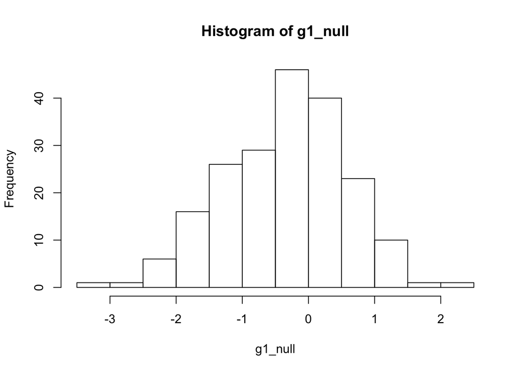

```r
richness <- 216
missing <- 15
#this simulates gamma values when trees are undersampled.
#we will grow trees with n=34 and prune them down to 13 taxa

num_simulations<-200 #number of simulations
g1_null<-numeric(num_simulations) #g1_null will hold the simulated gamma values
for(i in 1:num_simulations) {
  sim.bdtree(darterbirth, d=0, stop = "taxa", n=richness)->sim_tree
  drop.random(sim_tree, missing)->prune # prune down to the # of taxa in the phylogeny
    gammaStat(prune)->g1_null[i]
}
# create a histogram of the null distribution
hist(g1_null)

#arrow indicates where the observed gamma falls in the null you just generated
arrows(darter.gamma, 40, darter.gamma, 0, col="red", lwd=2)
```

```r
# Which of the null values are smaller (more negative) than the data?
smallerNull<-g1_null<=darter.gamma
# How many TRUEs are there?
count<-sum(smallerNull)

# finally, what is the p-value?
mccr_pval<-(count+1)/(num_simulations+1)
mccr_pval
```

```
## [1] 1
```

### 4. Exercise

1. Calculate the gamma statistic for this phylogeny of homalopsid snakes from [Alfaro et al., 2008](https://paperpile.com/shared/VusOOr): [snake.tre](https://www.dropbox.com/s/vpqe0338cxwpcjj/homalops.phy?dl=0).
2. Given this gamma value, what would you conclude about the tempo of speciation in this clade?
3. Given that the crown age of the snake radiation is 22 MY and the total richness of the clade is 34 species, determine whether the observed gamma could be due to the amount of incomplete sampling in the empirical tree. On the basis of the MCCR test what can you conclude about the tempo of homalopsid snake diversification?
4. What is the birth rate and death rate of the homalopsid tree.
5. Find a time-calibrated phylogeny for a group that interests you (ideally with more than 30 tips and fewer than 200). Do the following: (1) Describe the clade (including a description of the number of tips in the tree and the total number of species in the clades) and provide a reference or citation to the source. (2) Fit a birthdeath model to this tree and report b and d. (3) Perform an MCCR test and describe whether the gamma value is extreme or not given the level of sampling in the tree.

*Exercise modified from Liam J Revell’s Latin American Macroevolution Workshop 2016*